# Mixture distridution using EMclusting in R

## Description

- R에서 정규혼합분포의 추정과 군집화는 {mixtools}, {mclust}, {nor1mix}, {HDclassif}, {EMcluster} 등의 패키지를 통해 제공된다.
- 혼합분포군집은 **모형-기반(model-based)**의 군집 방법으로 각 데이터가 혼합분포 중 어느 모형으로부터 나왔을 확률이 높은지에 따라 분류가 이루어진다. 군집의 수는 분석자의 판단에 따라 유한개로 정해져야 한다. 단일 분포의 경우 일반적으로 Maximun Likelihood 방법을 사용하여 모수의 추정량을 구하지만 혼합 분포의 경우 가능도함수의 표현식이 복잡하기 때문에 닫힌 형태의 MLE를 구할 수 없게 된다. 따라서, 가능도 함수를 최대화시키는 모수를 찾는 대안적인 방안으로 반복 수치 최적알고리즘(iterative numerical optimization techniques)인 EM알고리즘을 사용한다.(Expectation-Maximization)
- 혼합분포군집에 대한 자세한 이론은 eeyem의 [혼합분포군집(mixture distribution clustering)](https://syj9700.tistory.com/39?category=850753) 포스팅을 통해 확인할 수 있다.

## Data

- 혼합분포군집에 대한 실습은 `mclust`패키지의 diabetes 데이터를 이용할 것이다.

```r
library(mclust)
data(diabetes)
summary(diabetes)
```

```
##       class       glucose       insulin            sspg
##  Chemical:36   Min.   : 70   Min.   :  45.0   Min.   : 10.0
##  Normal  :76   1st Qu.: 90   1st Qu.: 352.0   1st Qu.:118.0
##  Overt   :33   Median : 97   Median : 403.0   Median :156.0
##                Mean   :122   Mean   : 540.8   Mean   :186.1
##                3rd Qu.:112   3rd Qu.: 558.0   3rd Qu.:221.0
##                Max.   :353   Max.   :1568.0   Max.   :748.0
```

- 데이터는 3개의 타입(class)에 대한 당뇨병 환자에 대해 3개의 변수(glucose, insulin, sspg)를 측정한 자료이다. class를 모른다고 가정하고 3개의 변수를 이용하여 혼합푼포군집을 수행해보자.

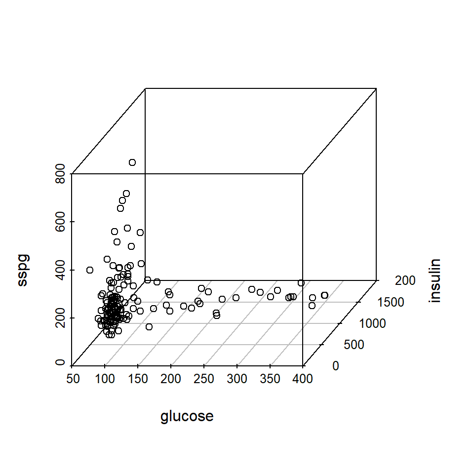

```r
library(scatterplot3d)
scatterplot3d(diabetes[2:4])
```

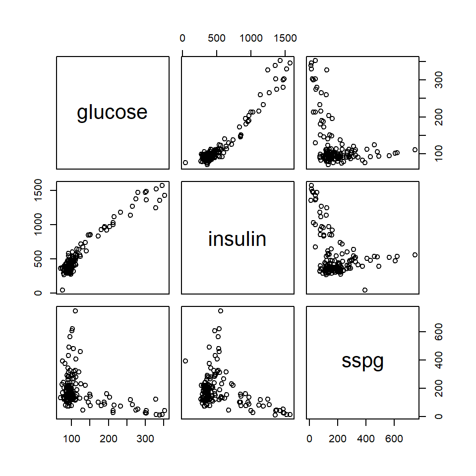

```r
plot(diabetes[2:4])
```

- 데이터의 분포를 2차원과 3차원에 나타낸 그림으로 퍼진 정도나 방향이 최소 2~3개 정도로 나뉘는 것으로 보인다. 따라서, 평균과 분산이 다른 2~3개의 분포가 혼합되었다고 예상할 수 있다.

## EM algorithm

```r
clust3 <- Mclust(diabetes[,2:4], G=2:4)
summary(clust3, parameters = TRUE)
```

```
## ----------------------------------------------------
## Gaussian finite mixture model fitted by EM algorithm
## ----------------------------------------------------
##
## Mclust VVV (ellipsoidal, varying volume, shape, and orientation) model with 3
## components:
##
##  log-likelihood   n df       BIC       ICL
##       -2303.496 145 29 -4751.316 -4770.169
##
## Clustering table:
##  1  2  3
## 81 36 28
##
## Mixing probabilities:
##         1         2         3
## 0.5368974 0.2650129 0.1980897
##
## Means:
##              [,1]     [,2]       [,3]
## glucose  90.96239 104.5335  229.42136
## insulin 357.79083 494.8259 1098.25990
## sspg    163.74858 309.5583   81.60001
##
## Variances:
## [,,1]
##          glucose    insulin       sspg
## glucose 57.18044   75.83206   14.73199
## insulin 75.83206 2101.76553  322.82294
## sspg    14.73199  322.82294 2416.99074
## [,,2]
##           glucose   insulin       sspg
## glucose  185.0290  1282.340  -509.7313
## insulin 1282.3398 14039.283 -2559.0251
## sspg    -509.7313 -2559.025 23835.7278
## [,,3]
##           glucose   insulin       sspg
## glucose  5529.250  20389.09  -2486.208
## insulin 20389.088  83132.48 -10393.004
## sspg    -2486.208 -10393.00   2217.533
```

- 군집의 개수를 2~4개를 고려하여 EM알고리즘을 수행한 결과이다. 최적의 군집 수는 3개로 판단되었으며, 각 군집에서 변수의 평균, 분산, 공분산과 군집의 사후확률, 최적 모형에 대한 정보가 출력된다.
- 모형은 세 영문글자로 표현되며, 첫 글자는 군집의 크기(volume), 두 번째 글자는 군집의 형태(shape), 세 번째 글자는 방향(orientation)을 의미한다. 표현되는 영문은 ‘E(equal)’, ‘V(variable)’, ‘I(coordinate axes)’으로 혼합분포군집의 결과로부터 도출된 VVV 모형은 3개 군집의 크기, 형태, 방향이 다른 모형으로 해석할 수 있다.

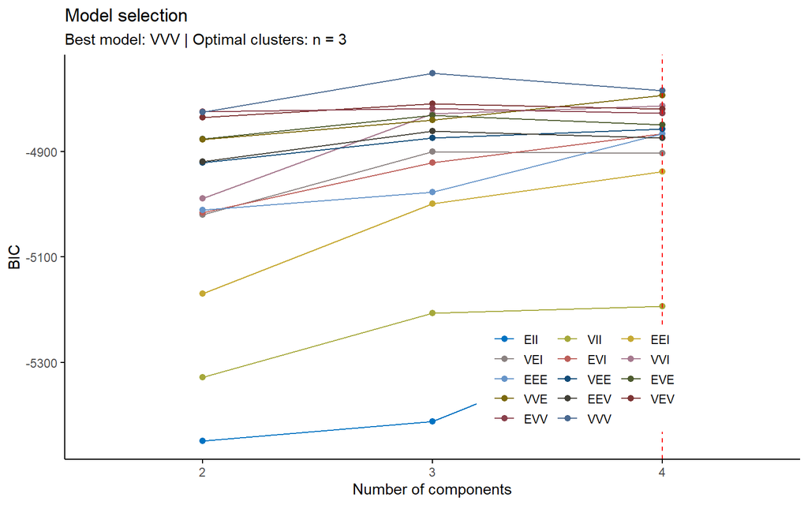

```r
library(factoextra)
fviz_mclust(clust3,"BIC", geom = "point",
            pointsize = 1.5, palette = "jco")
```

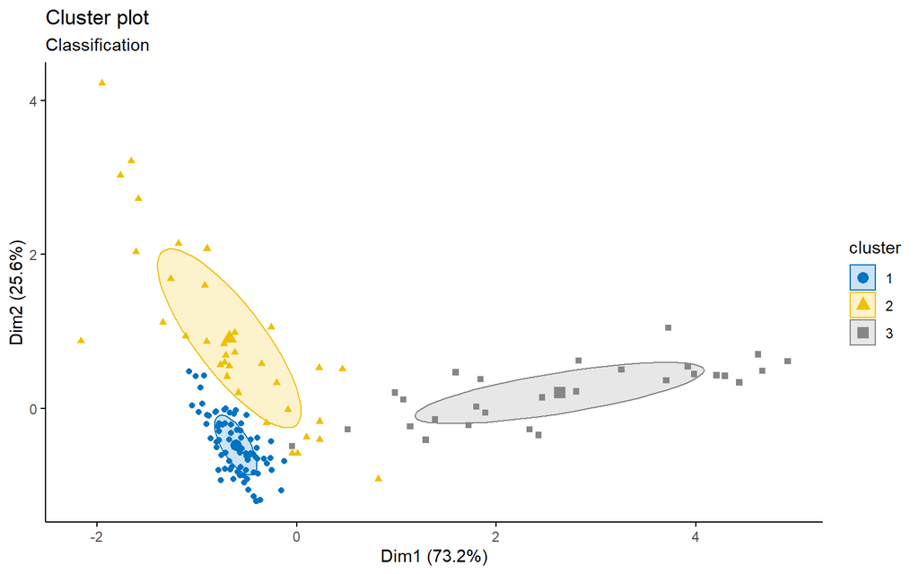

```r
fviz_mclust(clust3,"classification", geom = "point",
            pointsize = 1.5, palette = "jco")
```

- 군집 결과를 시각화한 그림으로 첫번째 그림은 혼합 분포 수에 따른 BIC를 모형별로 나타낸 것이고, 두번째 그림은 군집별로 산점도를 나타낸 것이다(파란점 : 군집 1, 노란점 : 군집 2, 회색점 : 군집3). 군집의 수를 2~4개 고려했을 때, 최종 모형은 BIC가 가장 작고((-)부호 제거) 군집수가 3개인 VVV모형이다.